# Intervalos de confiança para a média

ProbEst

fnaufel

Criado em 17/02/2021 Versão de 17/09/2021

# 1 Exemplo: preço médio da gasolina

- Em uma amostra aleatória de $48$ postos de gasolina, a média do preço de um litro de gasolina comum foi R$ $5{,}41$.
- De pesquisas anteriores, sabemos que o desvio padrão dos preços de gasolina *na população de todos os postos* é de R$ $1{,}09$.
- Vamos construir um intervalo de confiança de $95\%$ para a média *populacional* do preço do litro da gasolina.

## 1.1 Teoria

- Vamos identificar os dados:
  - Média amostral $\overline x = 5{,}41$.
  - Tamanho da amostra $n = 48$.
  - Desvio padrão populacional $\sigma = 1{,}09$.
  - Nível de confiança $c = 0{,}95$.
- Verifique que as condições para aplicar o TCL são satisfeitas aqui.
- O TCL diz que $\overline X$ tem distribuição amostral normal com média $\mu$ (a média populacional, que nunca vamos descobrir) e com desvio padrão

  $$EP \quad=\quad
  \frac{\sigma}{\sqrt{n}} \quad=\quad
  \frac{1{,}09}{\sqrt{48}} \quad=\quad
  0{,}16$$
- Eis a distribuição amostral da média, com os $95\%$ centrais de probabilidade em destaque:

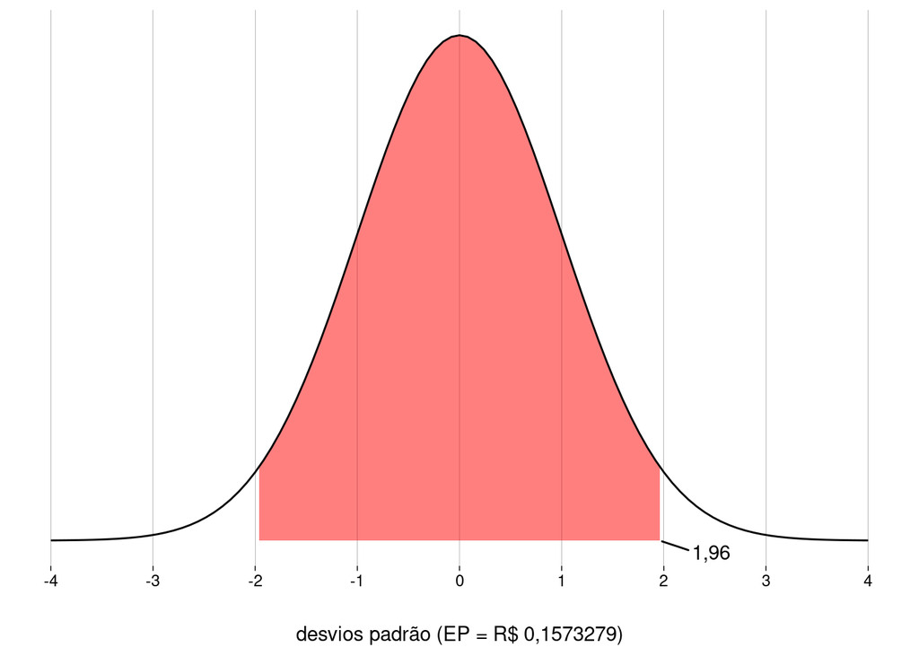

- O valor crítico correspondente a $c = 0{,}95$ é $z^\star = 1{,}96$.
- A margem de erro $ME$ vai ser $z^\star \cdot EP = 0{,}31$.
- O intervalo de confiança vai ser

  $$[\quad \overline x - 1{,}96 \cdot EP\quad,\quad \overline x + 1{,}96 \cdot EP\quad]
  \quad=\quad
  [\quad 5{,}10 \quad,\quad 5{,}72 \quad]$$

## 1.2 Em R

- Este procedimento é chamado de teste z.
- Este teste pressupõe que você sabe o desvio padrão populacional; esta situação é tão rara que o R base não tem uma função para isso. Na verdade, o teste z é usado principalmente para fins didáticos.
- Vamos carregar um pacote que implementa o teste z:

  ```r
  library(BSDA)
  ```

- Esta função recebe o resumo (*summary*) da amostra e constrói o intervalo de confiança:

  ```r
  zsum.test(mean.x = 5.41, sigma.x = 1.09, n.x = 48)
  ```

  ```
  ##
  ##  One-sample z-Test
  ##
  ## data:  Summarized x
  ## z = 34,387, p-value < 0,00000000000000022
  ## alternative hypothesis: true mean is not equal to 0
  ## 95 percent confidence interval:
  ##  5,101643 5,718357
  ## sample estimates:
  ## mean of x
  ##      5,41
  ```

- De novo, a mesma função calcula um intervalo de confiança e faz um teste de hipótese.

# 2 Exemplo: salmões

- Numa amostra de $150$ salmões, foi medida a concentração do contaminante *mirex* (um inseticida).
- As concentrações (em ppm) estão resumidas na tabela abaixo.

  | location | mirex |
  | --- | --- |
  | Chile | 0,055 |
  | Chile | 0,057 |
  | Chile | 0,052 |
  | Chile | 0,054 |
  | Chile | 0,057 |
  | Chile | 0,050 |
  | Chile | 0,058 |
  | Chile | 0,060 |
  | Chile | 0,052 |
  | Chile | 0,056 |

  [output cut: 140 more lines]

- A média foi $\overline x = 0{,}09$ppm.
- O desvio padrão *amostral* foi $s = 0{,}05$ppm.
- Não sabemos o desvio padrão *populacional*.
- Vamos construir um intervalo de confiança para a média *populacional* da concentração de *mirex*.

## 2.1 Teoria

- Como não sabemos $\sigma$, vamos usar $s$ em seu lugar.
- Vamos trabalhar com uma distribuição amostral da média $\overline X$ com média $\mu$ e erro padrão

  $$EP = \frac{s}{\sqrt{n}}$$
- No início do século $20$, [William Gosset](https://pt.wikipedia.org/wiki/William_Sealy_Gosset) descobriu que, quando substituímos $\sigma$ por $s$ no cálculo do erro padrão, a distribuição amostral deixa de ser normal e passa a ser a distribuição $t$ de Student. Leia mais [neste site sobre história da Estatística](https://estatisticaeetag.blogspot.com/?view=classic); busque no nome de Gosset para achar o trecho sobre ele.
- Além disso, temos mais uma condição a ser verificada: quanto menor o tamanho da amostra, mas próximas da normal a distribuição da população e a distribuição da amostra precisam ser, para o método dar certo.
- No nosso caso, como $n = 150$, não precisamos nos preocupar muito. De qualquer forma, eis um histograma da nossa amostra:

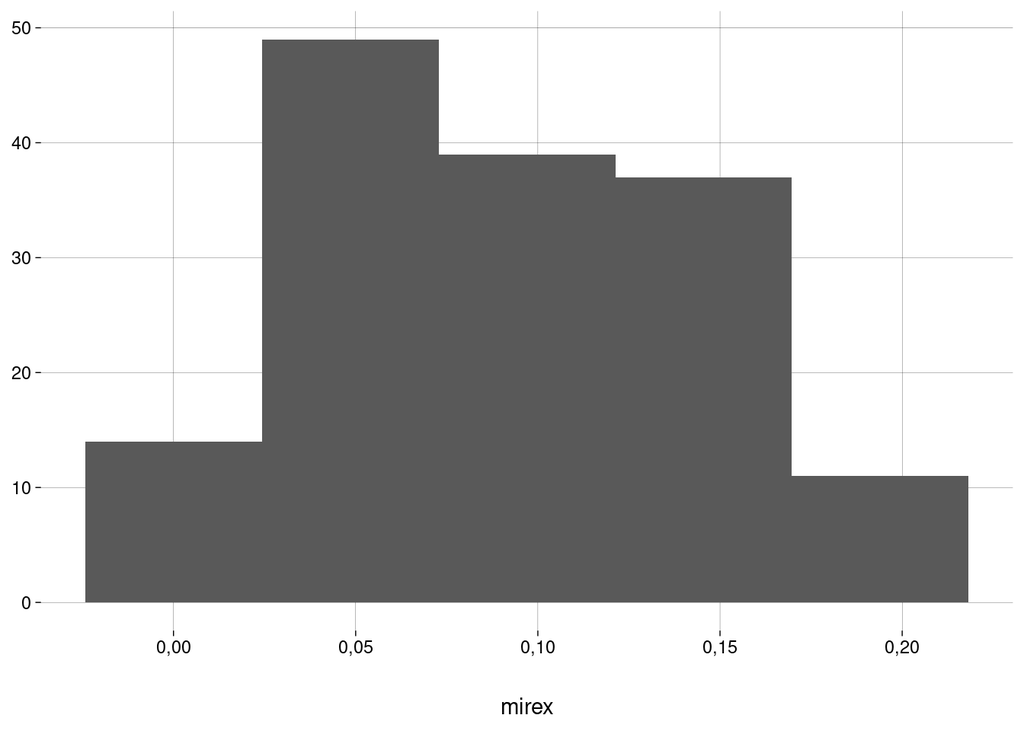

  O histograma é unimodal e aproximadamente simétrico. Isto basta.
- A distribuição $t$ é na verdade, uma família de distribuições, dependendo de um parâmetro chamado *número de graus de liberdade*, geralmente escrito como $\nu$ (falado “ni”).
- Quanto maior o valor de $\nu$, mais parecida com uma normal é a distribuição $t$, como mostra a figura:

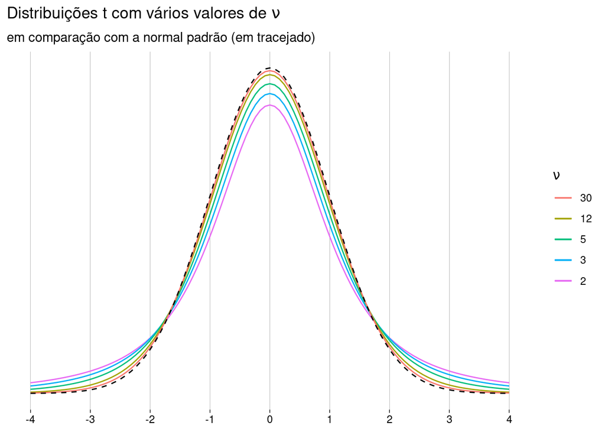

- A distribuição $t$ com $\nu$ graus de liberdade tem
  - Média $0$ (se $\nu > 1$; caso contrário, a média é indefinida).
  - Variância $\frac{\nu}{\nu -2}$ (se $\nu > 2$); variância infinita (se $1 < \nu \leq 2$); variância indefinida para todos os outros casos.
- No R, você pode usar as funções `dt`, `pt`, `qt` e `rt` para, respectivamente, computar a densidade, a probabilidade acumulada, os quantis e para sortear valores de acordo com a distribuição $t$.
- Quando nossa amostra tiver tamanho $n$, vamos trabalhar com a distribuição $t$ com $n - 1$ graus de liberdade.
- Então, no exemplo, $\nu = 150 - 1 = 149$.
- Computamos o intervalo de confiança como antes, mas o valor crítico agora vai ser dado não pela normal, mas sim pela distribuição $t$ com $149$ graus de liberdade:

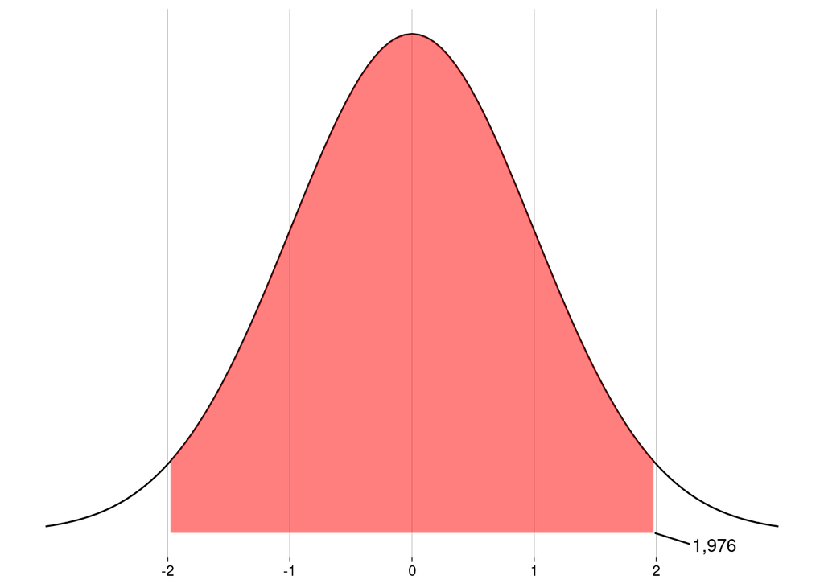

- Lembre-se de que, com a normal, o valor crítico para o nível de confiança de $95\%$ era $1{,}96$. Como a distribuição $t$ tem as caudas mais pesadas, aqui o valor crítico ficou um pouco maior: é preciso se afastar um pouco mais da média para obter $95\%$ da área sob a curva.
- A margem de erro vai ser

  $$ME \quad=\quad
  t^\star \cdot EP \quad=\quad
  t^\star \cdot \frac{s}{\sqrt{n}} \quad=\quad
  1{,}98 \cdot \frac{0{,}05}{12{,}25} \quad=\quad
  0{,}01$$
- O intervalo de confiança para a média populacional, com nível de confiança de $95\%$ é

  $$[\quad \overline x - ME \quad,\quad \overline x + ME \quad]
  \quad=\quad
  [\quad
  0{,}08
  \quad,\quad
  0{,}10\quad]$$

## 2.2 Em R

- Este procedimento é chamado de teste t.
- No R base, use a função `t.test`, que também faz teste de hipóteses.

  ```r
  t.test(x = salmoes$mirex)
  ```

  ```
  ##
  ##  One Sample t-test
  ##
  ## data:  salmoes$mirex
  ## t = 22,589, df = 149, p-value < 0,00000000000000022
  ## alternative hypothesis: true mean is not equal to 0
  ## 95 percent confidence interval:
  ##  0,08334978 0,09933022
  ## sample estimates:
  ## mean of x
  ##   0,09134
  ```

# 3 Exercícios

## 3.1 Uma função para o teste z

- Implemente a sua própria função para construir um intervalo de confiança quando $\sigma$ é conhecido. Os parâmetros devem ser
  - $\overline x$
  - $n$
  - $\sigma$
  - `conf`: o nível de confiança, um valor entre $0$ e $1$
- Teste sua função com vários exercícios do livro. Compare com os resultados de `BSDA::zsum.test`.

## 3.2 Uma função para o teste t

- Implemente a sua própria função para construir um intervalo de confiança quando $\sigma$ não é conhecido. Os parâmetros devem ser
  - $\overline x$
  - $n$
  - $s$
  - `conf`: o nível de confiança, um valor entre $0$ e $1$
- Teste sua função com vários exercícios do livro. Compare com os resultados de `t.test`.

## 3.3 Tamanho mínimo da amostra

- Reveja a aula sobre intervalos de confiança para proporções. Lá, falamos sobre como calcular $n$ em função do nível de confiança e da margem de erro desejada.
- Faça o mesmo para o teste t. Isto é, obtenha uma fórmula que dê o valor mínimo de $n$ em função do nível de confiança $c$ e da margem de erro $ME$.